# Внешний курс. Блок 3 - Криптография на практике

Основы информационной безопасности

Ефремова Полина Александровна

1132246726@rudn.ru

Российский университет дружбы народов

2026-05-16

# Информация

## Докладчик

- Ефремова Полина Александровна
- бакалавр
- Российский университет дружбы народов
- 1132246726@rudn.ru
- Доклад по теме: Внешний курс Stepik: “Основы кибербезопасности”

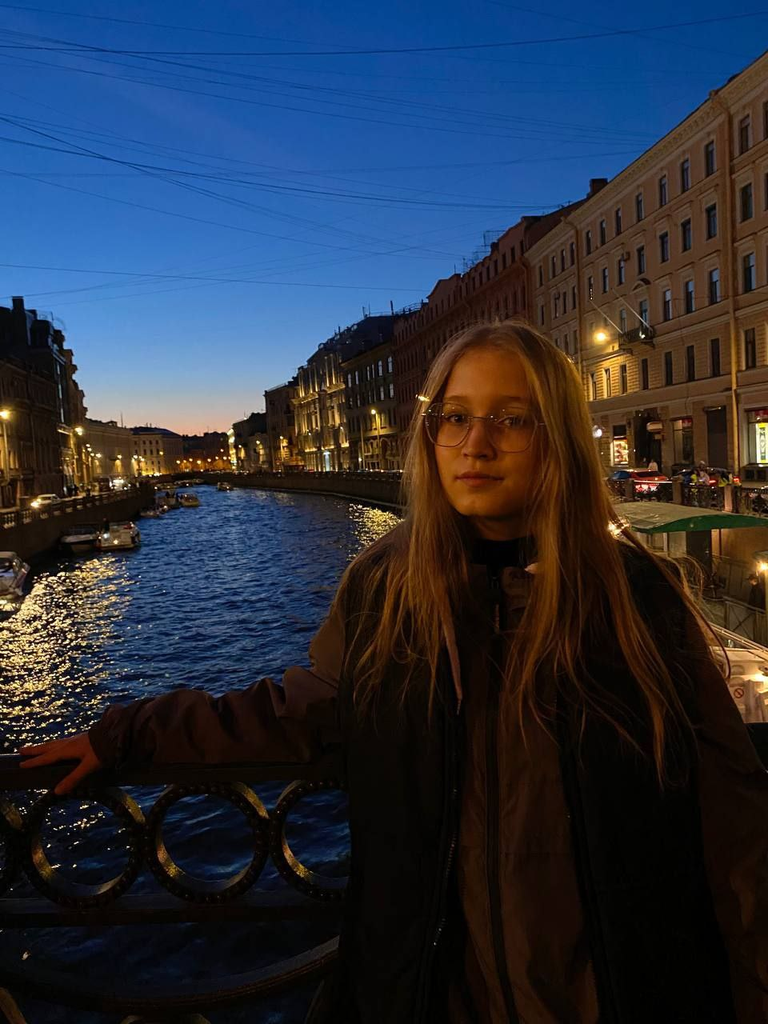

# Вводная часть

## Актуальность

- Широкое применение криптографии
- Необходимость защиты цифровых данных
- Использование электронной подписи и шифрования

## Объект и предмет исследования

### Объект исследования:

Криптографические системы защиты информации

### Предмет исследования:

Алгоритмы шифрования, цифровая подпись и криптографические протоколы

## Цели и задачи

Цель - изучение практического применения криптографических механизмов

Задачи:

- изучить симметричную криптографию;
- рассмотреть электронную подпись;
- исследовать хэш-функции;
- изучить криптографические механизмы блокчейна

## Материалы и методы

Материалы:

- курс Stepik;
- криптографические алгоритмы;
- тестовые задания

Методы:

- анализ криптографических примитивов;
- изучение практических сценариев применения;
- сравнение алгоритмов

# Основная часть - Выполнение заданий 3 блока

## Введение в криптографию

Для ответа на вопрос используется определение ассиметричного шифрования с двумя ключами.

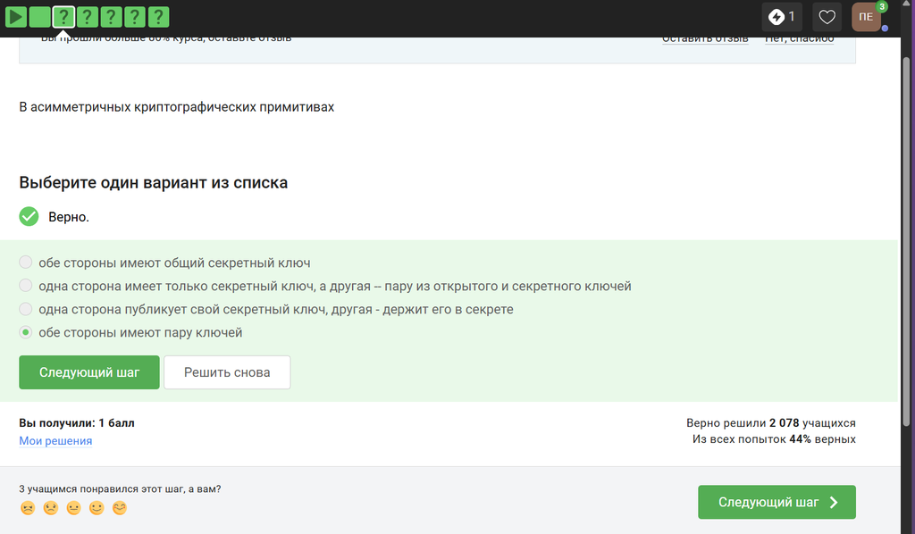

Рисунок 1: Вопрос 1

Отмечены основные условия для криптографической хэш-функции.

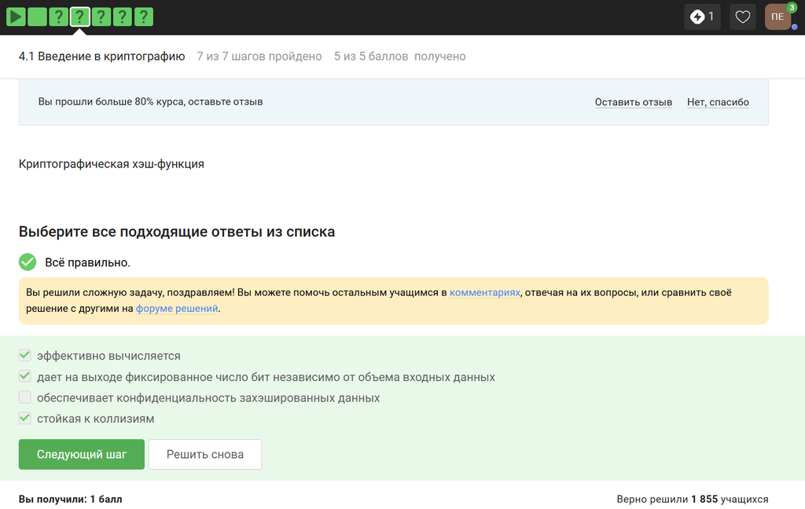

Рисунок 2: Вопрос 2

Отмечены алгоритмы цифровой подписи.

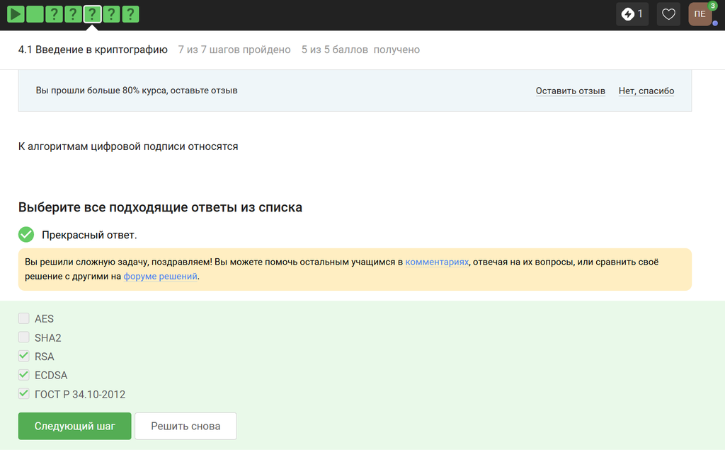

Рисунок 3: Вопрос 3

В информационной безопасности аутентификация сообщения или аутентификация источника данных - это свойство, которое гарантирует, что сообщение не было изменено во время передачи (целостность данных), и что принимающая сторона может проверить источник сообщения .

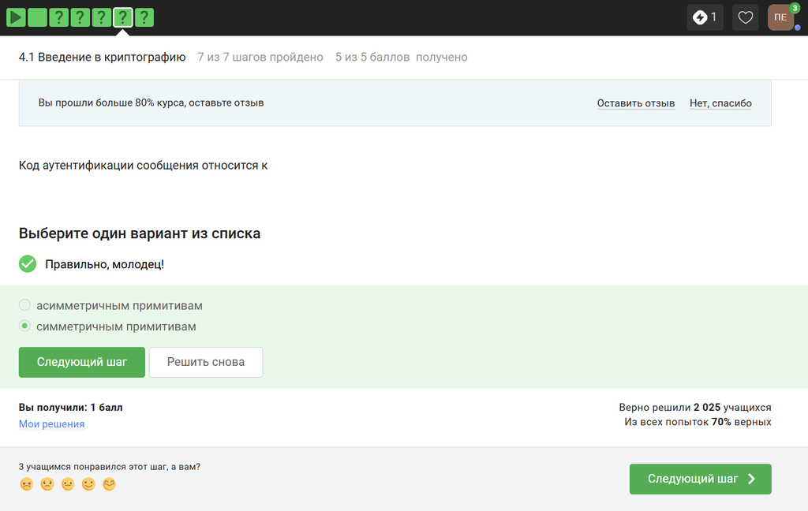

Рисунок 4: Вопрос 4

Верно дано определение обмена ключами Диффи-Хэллмана.

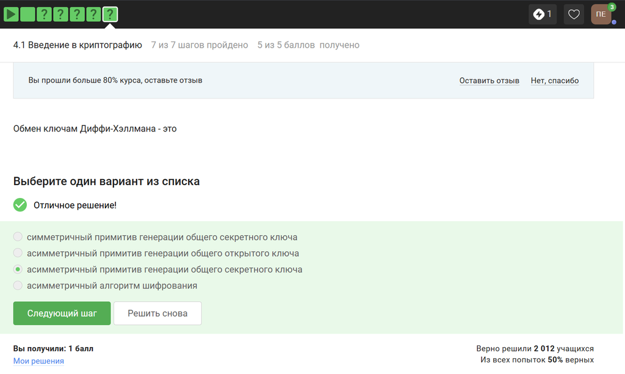

Рисунок 5: Вопрос 5

## Цифровая подпись

По определению цифровой подписи протокол ЭЦП относится к протоколам с публичным ключом.

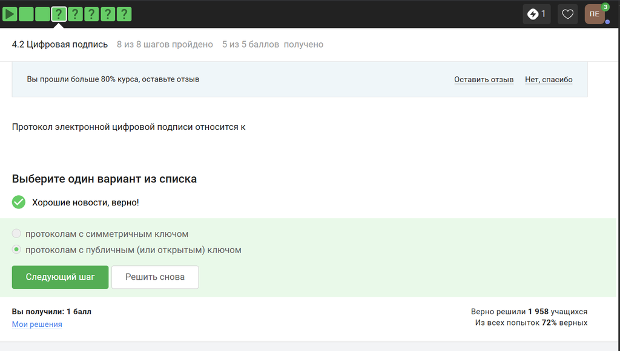

Рисунок 6: Вопрос 6

На первом этапе получатель сообщения строит собственный вариант хэш-функции подписанного документа. На втором этапе происходит расшифровка хэш-функции, содержащейся в ообщении, с помощью открытого ключа отправителя. На третьем этапе производится сравнение двух хэш-функций. Их совпадение гарантирует одновременно подлинность содержимого документа и его авторства.

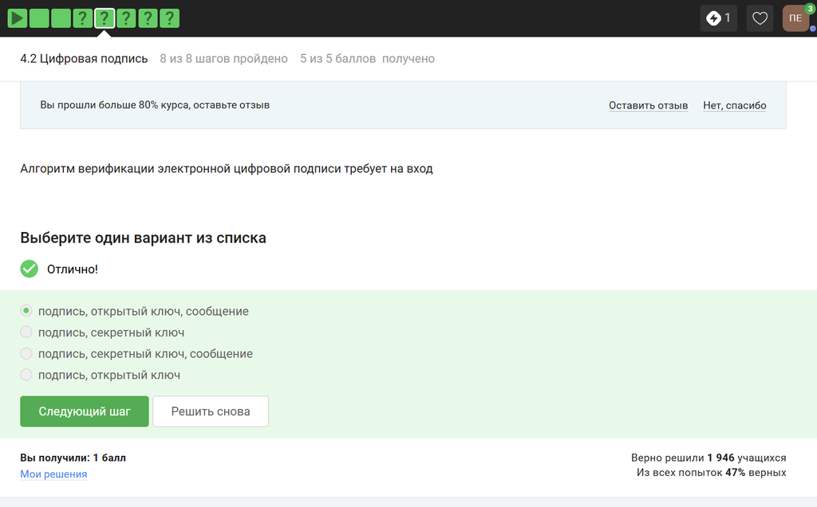

Рисунок 7: Вопрос 7

Электронная подпись обеспечивает всё указанное, кроме конфиденциальности.

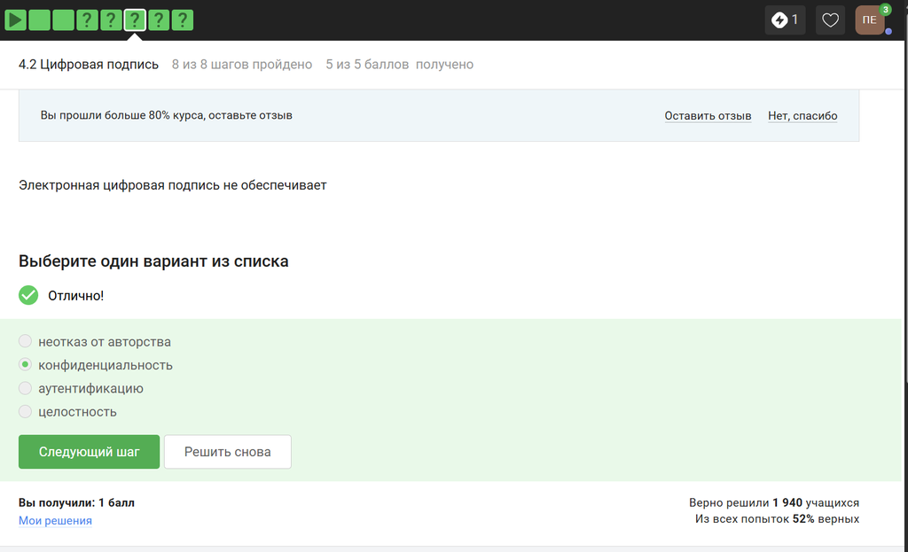

Рисунок 8: Вопрос 8

Для отправки налоговой отчётности в ФНС используется усиленная квалифицированная электронная подпись.

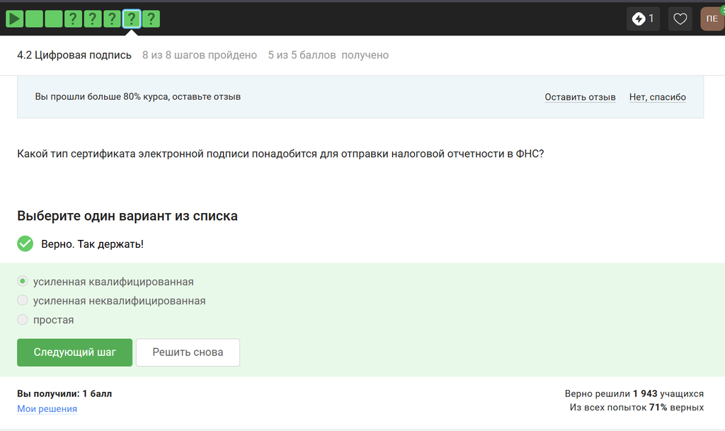

Рисунок 9: Вопрос 9

Верный ответ указан на изображении.

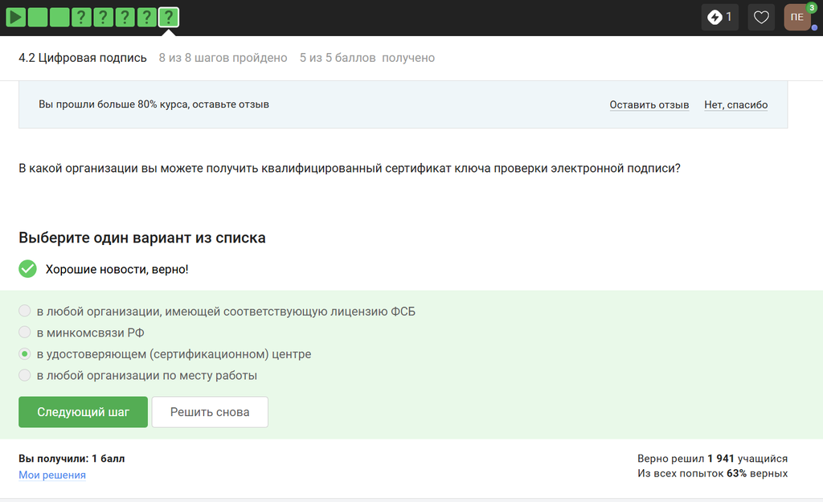

Рисунок 10: Вопрос 10

## Электронные платежи

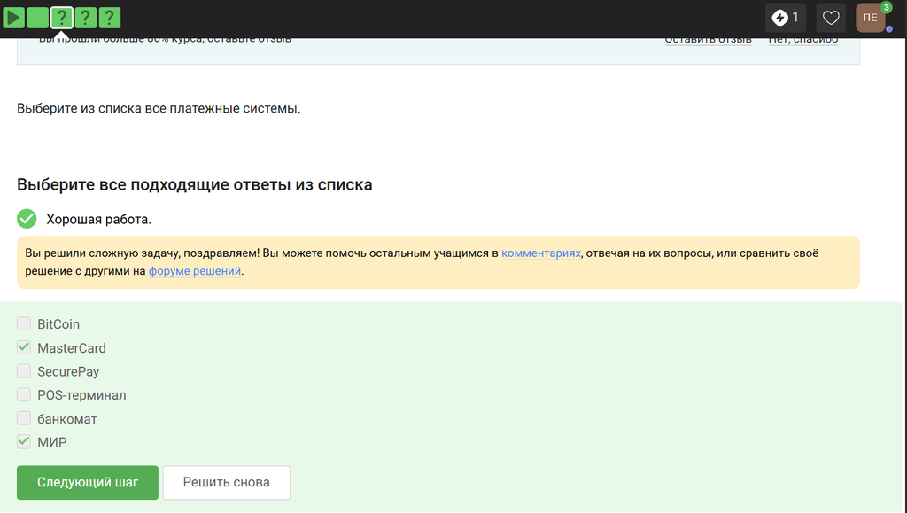

Рисунок 11: Вопрос 11

Верные варианты на изображении.

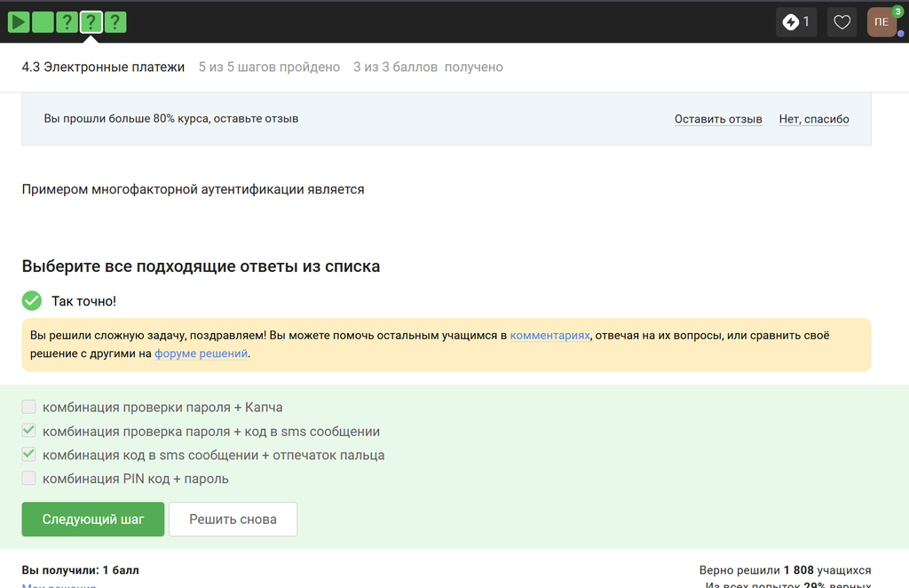

Рисунок 12: Вопрос 12

При онлайн-платежах используется многофакторная аутентификация.

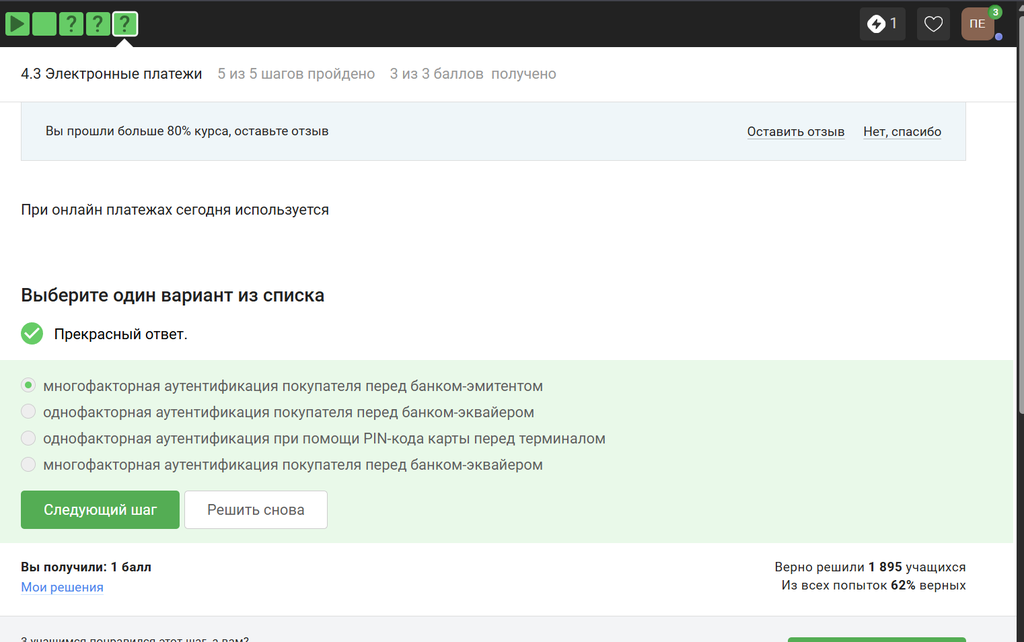

Рисунок 13: Вопрос 13

## Блокчейн

Proof-of-Work (PoW, доказательство выполнения работы) - это алгоритм достижения консенсуса в блокчейне. Он используется для подтверждения транзанкций и создания новых блоков. С помощью PoW майнеры конкурируют друг с другом за завершение транзакций в сети и за вознаграждение. Пользователи сети отправляют друг другу цифровые токены, после чего все транзакции собираются в блоки и записываются в распределённый реестр, то есть, в блокчейн.

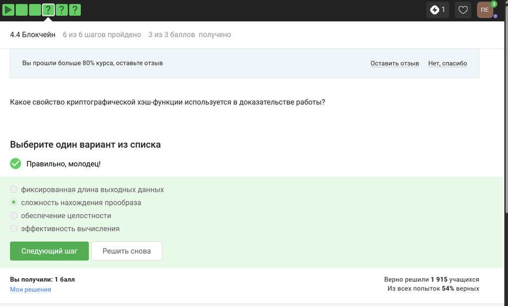

Рисунок 14: Вопрос 14

Консенсус блокчейна - это процедура, в ходе которой участники сети достигают согласия о текущем состоянии данных в сети. Благодаря этому алгоритмы консенсуса устанавливают надёжность и доверие к самой сети.

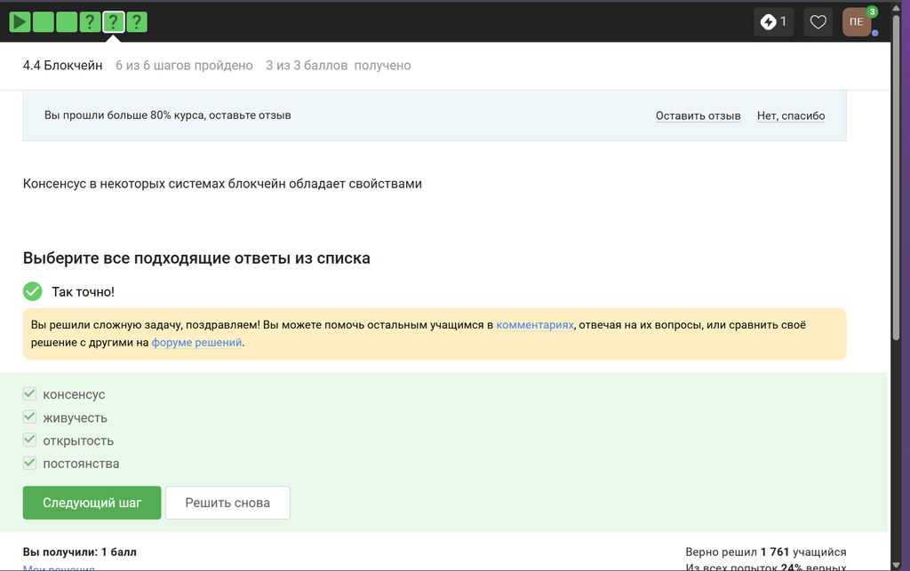

Рисунок 15: Вопрос 15

Ответ - цифровая подпись.

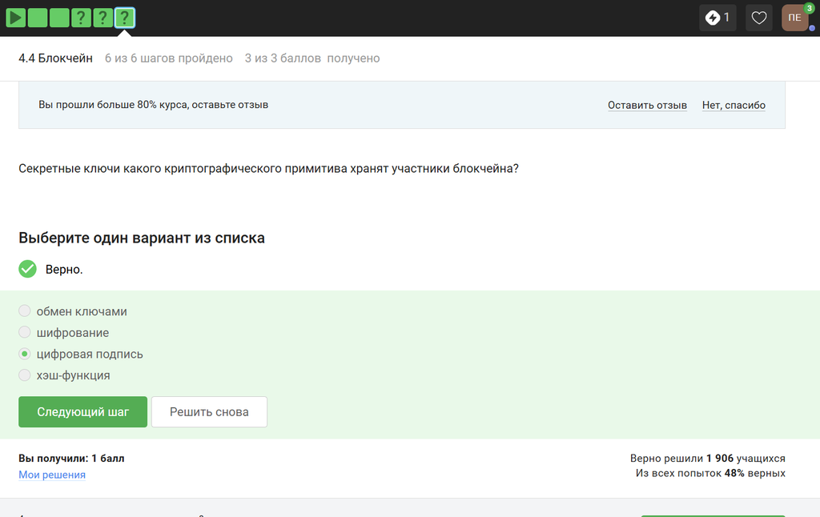

Рисунок 16: Вопрос 16

Все задания курса выполнены, мне пришла информация о прохождении, но сертификат не выдаётся.

# Анализ и практическая значимость

- Изучены современные криптографические механизмы
- Рассмотрены ЭЦП, хэш-функции и асимметричное шифрование
- Проанализировано применение криптографии в блокчейне
- Показано практическое значение криптографической защиты